# Chapter 5 - CCA: computer exercises

Author

Prof. Richard Wilkinson

### Task 1

Consider again the crabs dataset you looked at in the exercises in the chapter on PCA. We now consider a canonical correlation analysis in which one set of variables, the $\mathbf x$-set, is given by CL and CW and the other set, the $\mathbf y$-set, is given by FL, RW and BD.

```r
library(MASS)
?crabs           # read the help page to find out about the dataset
X1 = crabs |> dplyr::select(CL, CW)  |>as.matrix()
Y1 = crabs |> dplyr::select(FL, RW, BD) |> as.matrix()
```

```r
Sxx=cov(X1)
Syy=cov(Y1)       # find y-variable variance matrix
Sxy=cov(X1, Y1)       # find cross-covariance matrix
```

1. calculate ${\bf S}_{\bf x x}^{-1/2}$ and ${\bf S}_{\bf yy}^{-1/2}$ by first computing the spectral decomposition of $\mathbf S_{xx}$ and $\mathbf S_{yy}$.

**Solution**

```r
Sxx.svd <- svd(Sxx)
Syy.svd <- svd(Syy)
Sxx.isqrt <- Sxx.svd$u %*% diag(1/sqrt(Sxx.svd$d)) %*% t(Sxx.svd$v)
Syy.isqrt <- Syy.svd$u %*% diag(1/sqrt(Syy.svd$d)) %*% t(Syy.svd$v)
```

We can check that this is correct by checking that we get the identity matrix when expected:

```r
Sxx%*%Sxx.isqrt%*%Sxx.isqrt
```

```
            [,1]         [,2]
CL  1.000000e+00 1.953993e-14
CW -4.440892e-15 1.000000e+00
```

```r
Sxx.isqrt%*%Sxx%*%Sxx.isqrt #etc
```

```
             [,1]         [,2]
[1,] 1.000000e+00 6.217249e-15
[2,] 6.217249e-15 1.000000e+00
```

2. Now calculate the matrix $\mathbf Q$ and compute its singular value decomposition.

**Solution**

```r
Q=Sxx.isqrt%*%Sxy%*%Syy.isqrt            # calculate the A matrix (see Chapter 5)
(Q.svd = svd(Q))
```

```
$d
[1] 0.9901260 0.4836468

$u
           [,1]       [,2]
[1,] -0.7894005 -0.6138785
[2,] -0.6138785  0.7894005

$v
           [,1]       [,2]
[1,] -0.6490243 -0.2297495
[2,] -0.3210785  0.9469680
[3,] -0.6896927 -0.2246480
```

```r
U=Q.svd$u                # extract the U matrix (our notation) in svd
V=Q.svd$v                # extract the V matrix (our notation) in svd
d=Q.svd$d                # extract the singular values in svd
```

3. Compute the first pair of CC vectors and CC variables $\eta_1$ and $\psi_1$. What is the 1st canonical correlation?

**Solution**

```r
a = Sxx.isqrt%*%U[,1]         # calculate optimal x-weights
b = Syy.isqrt%*%V[,1]         # calculate optimal y-weights
eta1 = sweep(X1, 2, colMeans(X1)) %*%a   # calculate centred x-scores for 1st CC
psi1 = sweep(Y1, 2, colMeans(Y1))%*%b   # calculate centred y-scores for 1st CC
```

The first canonical correlation is the correlation between the first pair of CC vectors, which is the same as the first singular value.

```r
cor(eta1, psi1)
```

```
         [,1]
[1,] 0.990126
```

```r
d[1]
```

```
[1] 0.990126
```

4. Plot $\psi_1$ vs $\eta_1$. What does the plot tell you (if anything)?

**Solution**

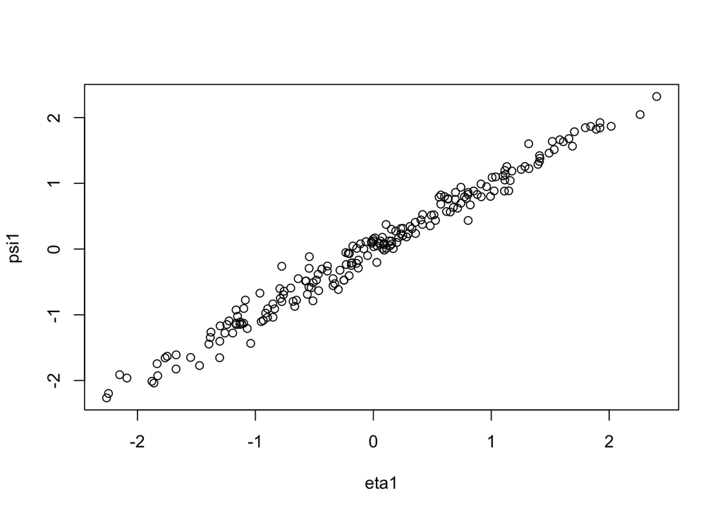

```r
plot(eta1,psi1)    # plot x-scores against y-scores for 1st CC
```

This just shows the high correlation (as expected by the first canonical correlation) between $\eta_1$ and $\psi_1$

22. Repeat the above to find the second pair of CC vectors, and the second set of CC variables/scores, and plot these against each other and against the first CC scores. Is there any interesting structure in any of the plots? Which plots suggest random scatter?

**Solution**

```r
a=Sxx.isqrt%*%U[,2]         # calculate optimal x-weights
b=Syy.isqrt%*%V[,2]         # calculate optimal y-weights
eta2=sweep(X1, 2, colMeans(X1))%*%a   # calculate centred x-scores for 2nd CC
psi2=sweep(Y1, 2, colMeans(Y1))%*%b   # calculate centred y-scores for 2nd CC
cor(eta2, psi2)
```

```
          [,1]
[1,] 0.4836468
```

```r
d[2]
```

```
[1] 0.4836468
```

If we plot eta2 against psi2 we can see some weak correlation, which fits with the second canonical correlation being 0.48. If we plot eta2 against eta1 or psi1, we can see there is no correlation, as expected by the definition of the CC variables.

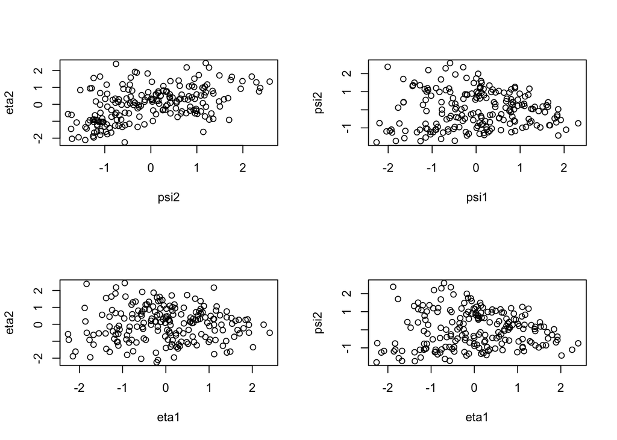

```r
par(mfrow=c(2,2))
plot(psi2, eta2)
plot(psi1, psi2)
plot(eta1, eta2)
plot(eta1, psi2)
```

6. Finally, repeat the analysis above using the `cc` command and `plt.cc` from the package `CCA` which you will need to download.

**Solution**

Note that circle plots are explained below in the solution to task 2.

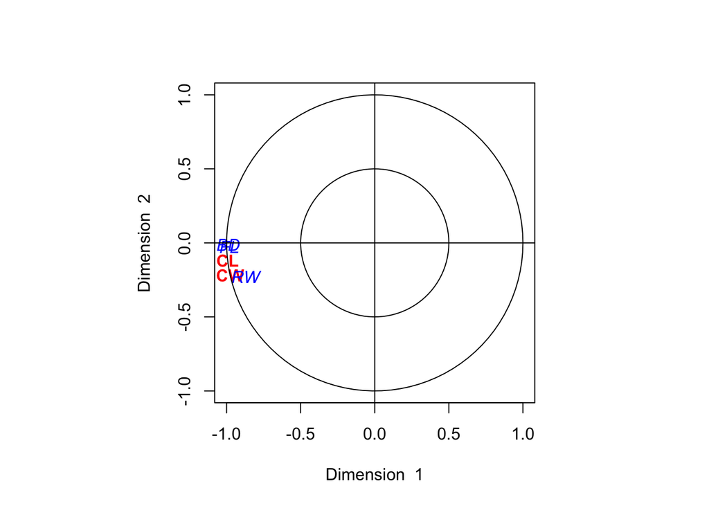

```r
library(CCA)
cca<-cc(X1,Y1)
plt.cc(cca, var.label=TRUE, type='v')
```

We can see the first X cc score ($\eta_1$) is highly negatively correlated with all of the respective original variables. This is because they are both just measuring the overall size of the crabs. If CL and CW are large, the RW, FL, and BD tend to be large.

The second X cc scores $\eta_2$ is only weakly correlated to the original variables

```r
cca$scores$corr.Y.xscores[,2]
```

```
         FL          RW          BD
-0.02732000 -0.22740190 -0.01305216
```

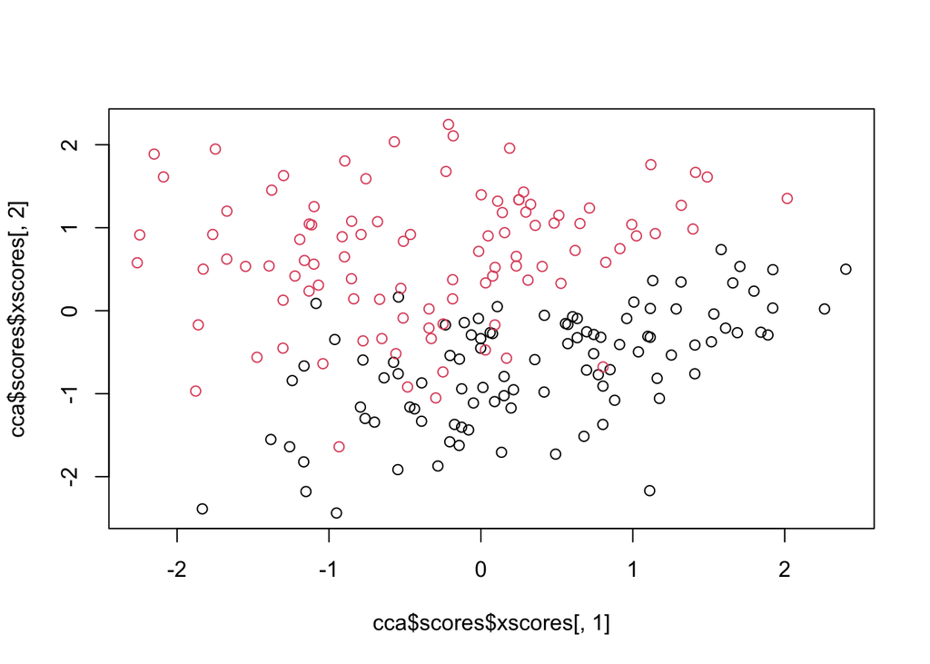

```r
plot(cca$scores$xscores[,1], cca$scores$xscores[,2], col=crabs$sp)
```

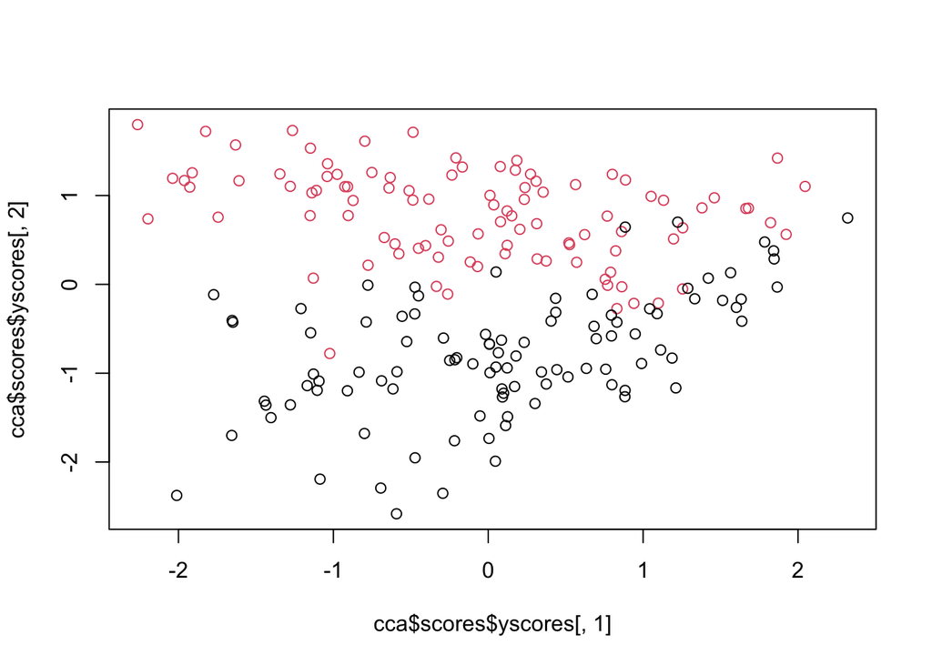

```r
plot(cca$scores$yscores[,1], cca$scores$yscores[,2], col=crabs$sex)
```

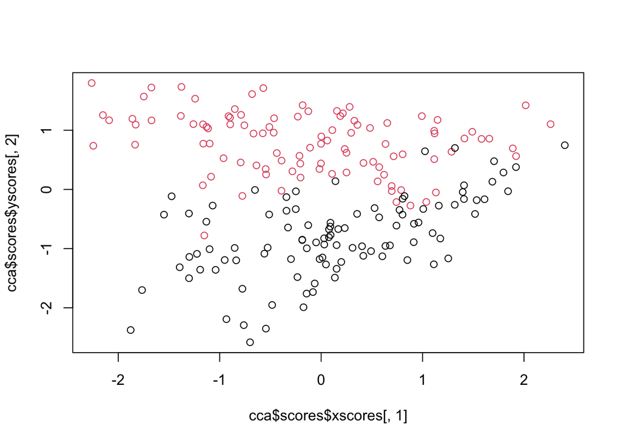

```r
plot(cca$scores$xscores[,1], cca$scores$yscores[,2], col=crabs$sex)
```

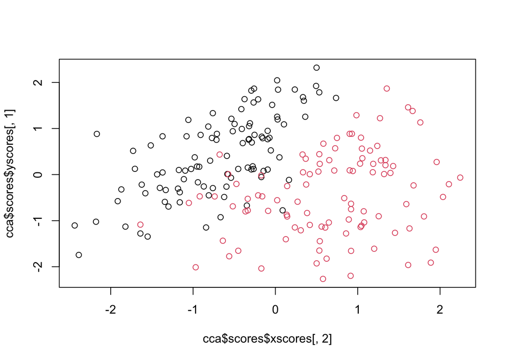

```r
plot(cca$scores$xscores[,2], cca$scores$yscores[,1], col=crabs$sp)
```

### Task 2

The data for previous Premier League seasons is available at:

https://www.rotowire.com/soccer/league-table.php?season=2022

There is a button to download the csv (comma separated variable) file in the bottom right hand corner. Read the data into R (hint: try the `read.csv` command).

```r
x <- read.csv(x , file="/YOURDIRECTORY/prem_league_data.txt,
sep=" ", header=TRUE)
```

If you are not sure what the name of YOURDIRECTORY is where the file is located, then a useful command to find out is `file.choose()`

1. Reproduce the analysis from the notes for the 2022-23 premier league season. Does the analysis produce a similar result as for the 2019-20 table?

**Solution**

```r
library(dplyr)
prem2223 <- read.csv('prem202223.csv')
# the data can be downloaded from https://www.rotowire.com/soccer/league-table.php
table <- prem2223 |> dplyr::select(Team, W, D, L, G, GA, GD)
X <- table[,c('W','D')] # W and D
Y <- table[,c('G','GA')] # G and GA
rownames(X)<- prem2223$Team
rownames(Y)<- prem2223$Team

library(CCA)
(prem.cca <- cc(X,Y))
```

```
$cor
[1] 0.9671956 0.4452870

$names
$names$Xnames
[1] "W" "D"

$names$Ynames
[1] "G"  "GA"

$names$ind.names
 [1] "Manchester City"        "Arsenal"                "Manchester United"
 [4] "Newcastle United"       "Liverpool"              "Brighton & Hove Albion"
 [7] "Aston Villa"            "Tottenham Hotspur"      "Brentford"
[10] "Fulham"                 "Crystal Palace"         "Chelsea"
[13] "Wolverhampton"          "West Ham United"        "AFC Bournemouth"
[16] "Nottingham Forest"      "Everton"                "Leicester City"
[19] "Leeds United"           "Southampton"


$xcoef
        [,1]       [,2]
W -0.1676667 0.01115769
D -0.1015198 0.36320806

$ycoef
          [,1]        [,2]
G  -0.03054968 -0.05935469
GA  0.04392604 -0.08569373

$scores
$scores$xscores
                             [,1]       [,2]
Manchester City        -1.8627265 -1.1949147
Arsenal                -1.6289130 -0.8540220
Manchester United      -1.1259130 -0.8874951
Newcastle United       -1.2674051  1.9735387
Liverpool              -0.8613258  0.5207064
Brighton & Hove Albion -0.4906194 -0.2168674
Aston Villa            -0.3890996 -0.5800754
```

[output cut: 41 more lines]

```

$scores$corr.Y.xscores
         [,1]       [,2]
G  -0.8607069 -0.2031206
GA  0.8599713 -0.2037799

$scores$corr.X.yscores
         [,1]       [,2]
W -0.93149323 -0.1198673
D  0.06422178  0.4443043

$scores$corr.Y.yscores
         [,1]       [,2]
G  -0.8898995 -0.4561566
GA  0.8891390 -0.4576371
```

2. Give an interpretation of the CC scores. One of doing this is to think about the correlation between the original variables and the scores (the transformed variables). Note that there are four different correlation matrices we can look at to aid interpretation: correlation between X and $\eta$, $X$ and $\psi$, $Y$ and $\eta$, and $Y$ and $\psi$.

Circle plots can also help. Look at the help page for `plt.cc` and try some circle plots.

**Solution**

We can use the correlations between the original and transformed variables to interpret the CC scores. These correlations are automatically computed when you do CCA in R. So for example, the correlation between X and $\eta$ is stored in

```r
# correlation between X and transformed x scores (eta)
prem.cca$scores$corr.X.xscores
```

```
         [,1]       [,2]
W -0.96308675 -0.2691912
D  0.06639999  0.9977931
```

```r
cor(X, prem.cca$scores$xscores)
```

```
         [,1]       [,2]
W -0.96308675 -0.2691912
D  0.06639999  0.9977931
```

The 3 other correlations of interest are

```r
# correlation between X and transformed y scores (psi)
prem.cca$scores$corr.X.yscores
```

```
         [,1]       [,2]
W -0.93149323 -0.1198673
D  0.06422178  0.4443043
```

```r
# correlation between Y and transformed x scores (eta)
prem.cca$scores$corr.Y.xscores
```

```
         [,1]       [,2]
G  -0.8607069 -0.2031206
GA  0.8599713 -0.2037799
```

```r
# correlation between Y and transformed y scores (psi)
prem.cca$scores$corr.Y.yscores
```

```
         [,1]       [,2]
G  -0.8898995 -0.4561566
GA  0.8891390 -0.4576371
```

Circle plots are useful ways of visualizing these correlations and can help us interpret the CCA output. They plot the correlation between the first two X CC scores ($\eta$) and the the original variables $X$ (in red) and $Y$ (in blue). I.e. they plot

```r
prem.cca$scores$corr.X.xscores
prem.cca$scores$corr.Y.xscores
```

```r
prem.cca$scores$corr.Y.xscores
```

```
         [,1]       [,2]
G  -0.8607069 -0.2031206
GA  0.8599713 -0.2037799
```

```r
prem.cca$scores$corr.X.yscores
```

```
         [,1]       [,2]
W -0.93149323 -0.1198673
D  0.06422178  0.4443043
```

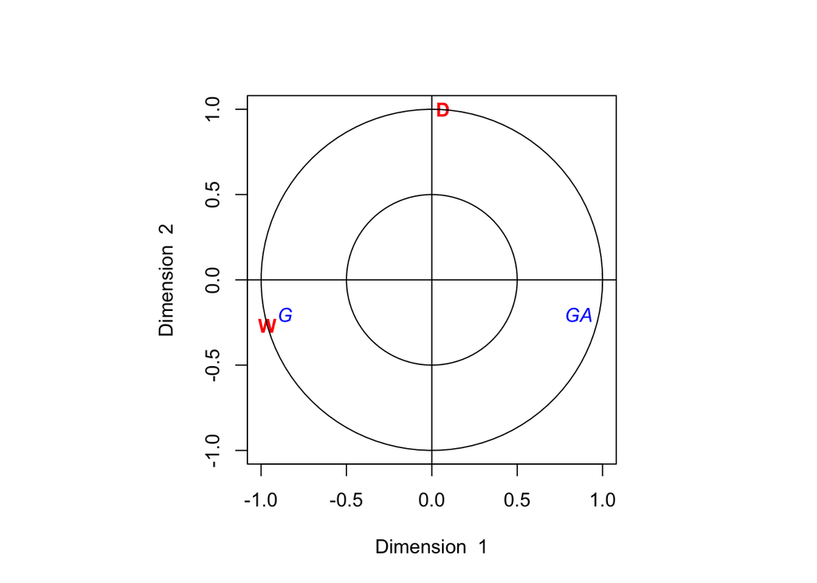

```r
plt.cc(prem.cca, var.label = TRUE,type='v',ind.names = table$Team)
```

So we can see that the first CC score for X ($\eta_1$) is highly negatively correlated with $W$ and $G$, and positively correlated with GA. This makes sense! If a team wins a lot we expect it to score a lot (large $G$) and concede rarely (low $GA$).

The second CC scores are less interesting here (because we only have 2 variables in X and Y, the second CC scores essentially are left to explain the remaining variability in the data). We can see that $\eta_2$ is strongly correlated with $D$, but unrelated to $G$ and $GA$.

To plot the correlation of the original variables with $\psi$ (the $Y$ CC scores), we have to change the order of the arguments to `cc`.

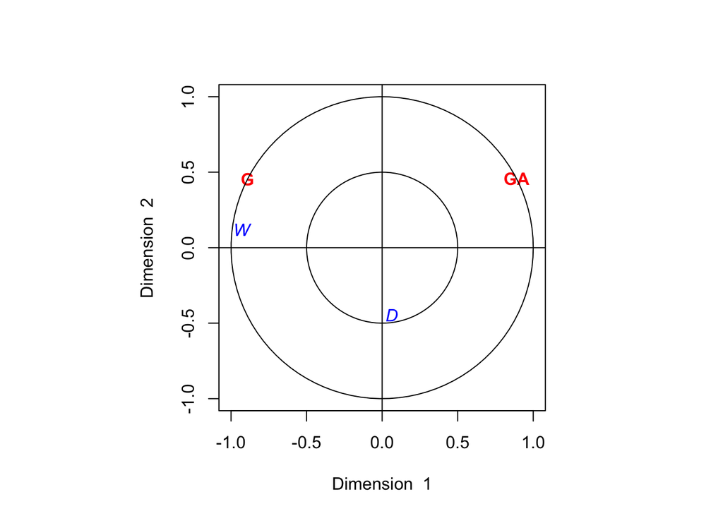

```r
prem.cca2 <- cc(Y,X)
plt.cc(prem.cca2, var.label = TRUE,type='v',ind.names = table$Team)
```

Swapping $X$ and $Y$ doesn’t change the underlying analysis, it just allows us to plot the other circle plot. We can see that $\psi_1$ (the first CC $Y$ score) is strongly positively correlated with GA, and negatively correlated with G and W. $\psi_2$ is weakly correlated with D, G and GA. Note that due to some numerical quirk, the sign of the second score is reversed compared with when we did `cc(X,Y)`.

The first pair of canonical correlation vectors are very similar to what we found for the 2019-20 season, with a similar first canonical correlation.

3. Consider now doing CCA with $\mathbf x=(W,D)$ and $\mathbf y=(G,GA, L)$. Note that if you knew $W$ and $D$, you could calculate $L$. Without doing any computation, what do you expect the first canoncial correlation to be? What will the first pair of CC vectors be (upto a multiplicative constant)?

**Solution**

The first canonical correlation is the correlation between a linear combination of $\mathbf x$ and a linear combination of $\mathbf y$ that is largest. Given that the correlation between $W$ and $D$ with $L$ is 1, we expect the first canonical correlation to be 1, achieved with CC vectors
$$\mathbf a_1 \propto(1\; 1)^\top \qquad \mathbf b_1 \propto (0\; 0\; -1)^\top$$
This is because we know $W+D+L=38$ for every team (every team plays every other team twice).

4. Check your intuition by doing the calculation in R:

**Solution**

```r
X <- table[,c('W','D')]
Y <- table[,c('G','GA','L')]
prem.cca2<-cc(X,Y)
prem.cca2$cor
```

```
[1] 1.0000000 0.6504055
```

```r
prem.cca2$xcoef
```

```
        [,1]        [,2]
W -0.1668436 -0.01999535
D -0.1668436  0.33821530
```

```r
prem.cca2$ycoef
```

```
            [,1]        [,2]
G  -5.551115e-17 -0.10374517
GA  6.245005e-17  0.06634862
L   1.668436e-01 -0.38272979
```

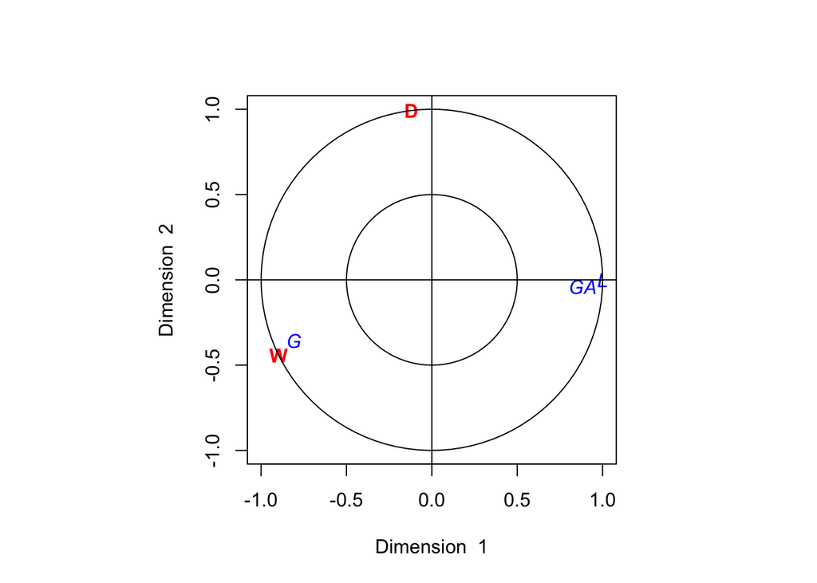

```r
plt.cc(prem.cca2, type='v', var.label = TRUE)
```

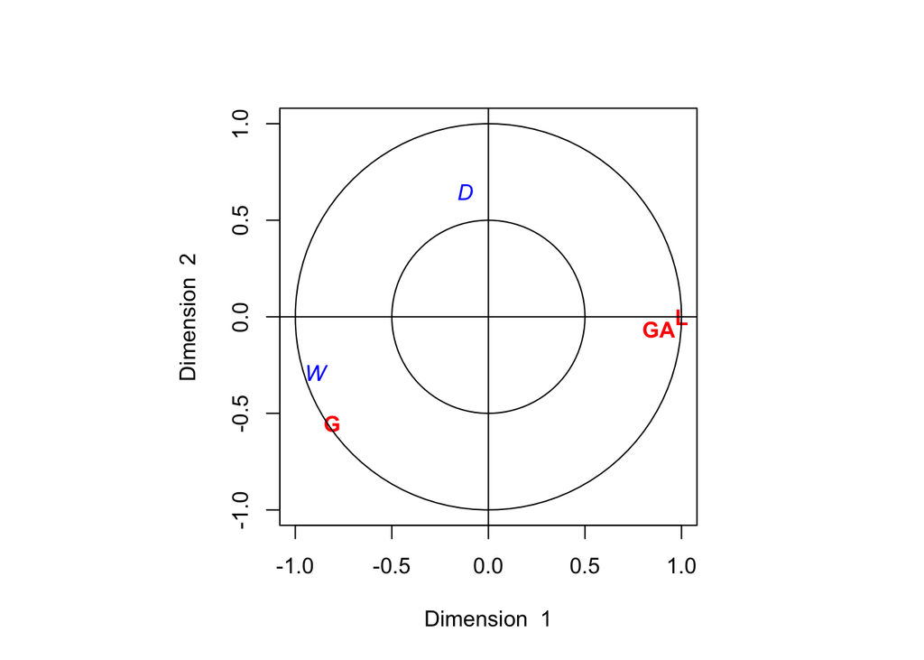

```r
prem.cca3<-cc(Y,X)
plt.cc(prem.cca3, type='v', var.label = TRUE)
```

### Task 3

We will now look data measured from 600 first year university students. Measurements were made on three psychological variables:

- Locus of Control: the degree to someone believes that they, as opposed to external forces, have control over the outcome of events in their lives.
- Self Concept: an indication of whether a person tends to hold a generally positive and consistent or negative and variable self-view.
- Motivation: how motivated an individual is

which will form our $\mathbf X$ variables. The $\mathbf Y$ variables are four academic scores (standardized test scores)

- Reading
- Writing
- Math
- Science

and gender (1=Male, 0 = Female) We are interested in how the set of psychological variables relates to the academic variables and gender.

```r
mm <- read.csv("https://stats.idre.ucla.edu/stat/data/mmreg.csv")
colnames(mm) <- c("Control", "Concept", "Motivation", "Read", "Write", "Math",
    "Science", "Sex")
psych <- mm[, 1:3]
acad <- mm[, 4:7]
```

Conduct CCA on these data. Provide an interpretation of your results.

**Solution**

```r
#matcor(psych, acad)
cc1 <- cc(psych, acad)

cc1$cor
```

```
[1] 0.44643648 0.15335902 0.02250348
```

The first canonical correlation is moderate and shows there is some link (but not a strong link) between some combination of the psych variables and the academic variables. The second and third canonical correlations are close to zero and so probably not worth looking at in detail.

We’re interested in the cross correlations: what the academic variables tell us about the pysch variables, and what the pysch variables tell us about the academic variables. Let’s look at these correlations.

We can visualize these on a circle plot.

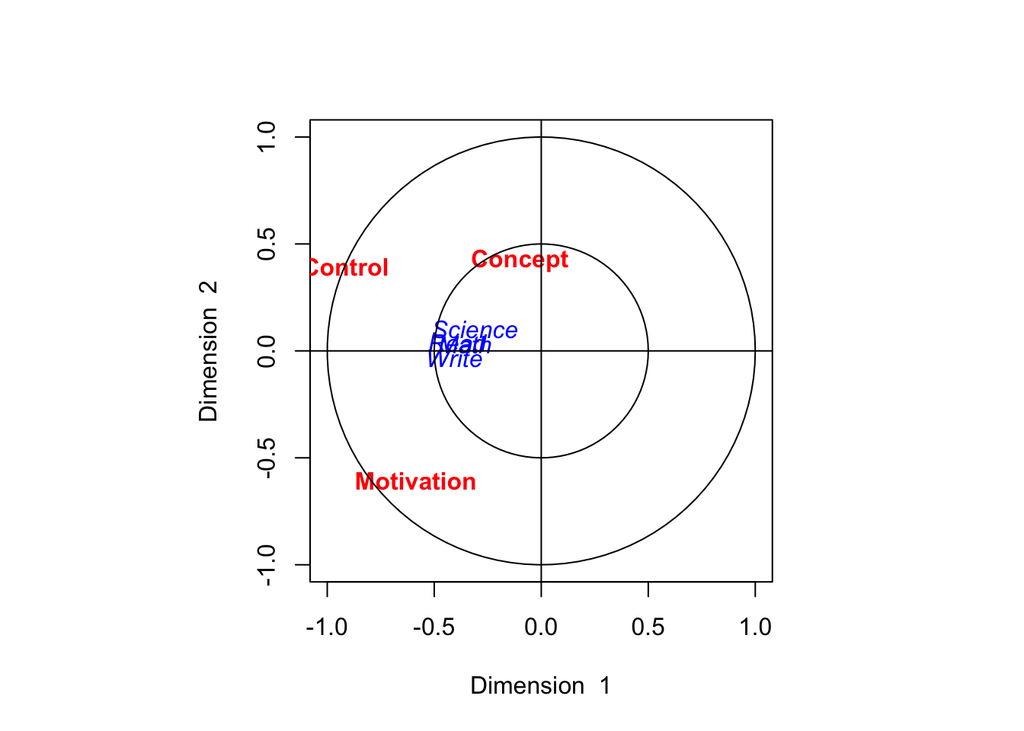

```r
plt.cc(cc1, var.label = TRUE, type='v')
```

```r
cc1$scores$corr.X.xscores
```

```
                  [,1]       [,2]        [,3]
Control    -0.91428518  0.3936580  0.09547756
Concept    -0.09996773  0.4213083 -0.90139104
Motivation -0.58532551 -0.6061228 -0.53852502
```

```r
cc1$scores$corr.Y.xscores
```

```
              [,1]        [,2]         [,3]
Read    -0.3930571  0.03755922 -0.006144737
Write   -0.4063141 -0.03388766  0.007646605
Math    -0.3571452  0.02882125 -0.006381333
Science -0.3098729  0.10365354  0.005348465
```

If instead we swap the order of the data sets in the `cc` command, then `plt.cc` plots the correlations with the acad CC scores.

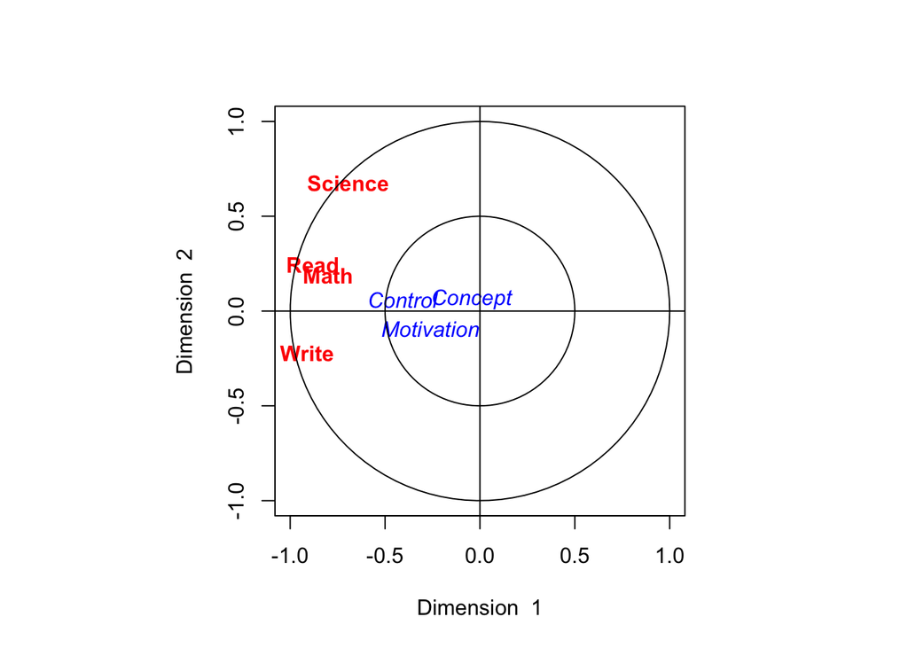

```r
plt.cc(cc(acad,psych), var.label = TRUE, type='v')
```

```r
cc1$scores$corr.X.yscores
```

```
                  [,1]        [,2]         [,3]
Control    -0.40817026  0.06037101  0.002148577
Concept    -0.04462924  0.06461142 -0.020284434
Motivation -0.26131066 -0.09295440 -0.012118686
```

```r
cc1$scores$corr.Y.yscores
```

```
              [,1]       [,2]       [,3]
Read    -0.8804322  0.2449104 -0.2730572
Write   -0.9101273 -0.2209695  0.3397966
Math    -0.7999910  0.1879332 -0.2835709
Science -0.6941031  0.6758881  0.2376728
```

Either way, the interpretation is the same. There is a moderate strength link between locus of control and motivation, and performance in the academic subjects. Self concept appears to be unrelated to academic performance.